# Algoritma dan Pemograman

Weksi Budiaji

2025-09-02

## 1. Pendahuluan

Dalam konteks pemrograman, bahasa dapat dikategorikan menjadi dua tingkat utama: low-level dan high-level. Bahasa low-level, seperti bahasa mesin yang terdiri hanya dari kode biner (0 dan 1), merupakan bahasa yang secara langsung dipahami dan dieksekusi oleh prosesor komputer. Bahasa ini sangat cepat untuk dijalankan oleh mesin namun hampir tidak mungkin dipahami dan ditulis langsung oleh manusia karena sangat abstrak dan tidak intuitif. Sebaliknya, bahasa high-level dirancang untuk lebih mudah dipahami oleh manusia karena menggunakan struktur dan kosakata yang mendekati bahasa manusia sehari-hari, seperti bahasa Inggris. Contoh bahasa **high-level** yang populer adalah C++, PHP, Java, dan R. Bahasa-bahasa ini kemudian akan diterjemahkan ke dalam bahasa mesin oleh kompiler atau interpreter agar dapat dijalankan oleh komputer.

Sementara bahasa pemrograman berkomunikasi dengan mesin, manusia membutuhkan cara untuk merancang dan mendokumentasikan algoritma sebelum diterjemahkan ke dalam kode. Untuk itu, digunakan berbagai bentuk **tulisan (text)**. Bentuk ini dapat berupa deskripsi menggunakan bahasa alami, seperti Bahasa Indonesia atau Inggris, yang menjelaskan langkah-langkah algoritma secara naratif. Namun, untuk menghindari ambiguitas yang sering muncul dalam bahasa alami, sering digunakan pseudocode. **Pseudocode** adalah notasi menyerupai kode program yang menggunakan struktur logika pemrograman (seperti IF, THEN, ELSE, WHILE) namun bebas dari sintaks spesifik suatu bahasa, sehingga fokus pada logika penyelesaian masalah tanpa terikat aturan teknis.

Selain representasi tekstual, algoritma sering kali divisualisasikan dalam bentuk **gambar (drawing)** untuk memberikan pemahaman yang lebih intuitif dan menyeluruh tentang alur proses. Bentuk yang paling umum adalah **flowchart atau diagram alir**, yang menggunakan simbol-simbol standar (seperti oval untuk mulai/selesai, jajaran genjang untuk input/output, dan belah ketupat untuk keputusan) yang dihubungkan dengan anak panah untuk menggambarkan urutan dan percabangan langkah secara jelas. Visualisasi ini sangat efektif untuk melacak alur logika yang kompleks dan merupakan alat bantu yang powerful dalam tahap analisis dan desain sistem.

Selain flowchart, terdapat beberapa teknik diagram lain yang digunakan untuk memodelkan algoritma dan sistem secara lebih terstruktur. **HIPO (Hierarchical Input Process Output)** adalah teknik dokumentasi yang berfokus pada hierarki fungsi dalam sebuah sistem, mendefinisikan input, proses, dan output untuk setiap modul, sehingga sangat baik untuk perancangan top-down. Sementara itu, **structure chart** khusus digunakan untuk memvisualisasikan struktur modul dari sebuah program dan hubungan pemanggilan antar modul, yang sangat berguna dalam pemrograman terstruktur. Kombinasi antara representasi tulisan (terutama pseudocode) dan gambar (seperti flowchart) memberikan fondasi yang kuat dan jelas sebelum proses penulisan kode dalam bahasa pemrograman high-level dimulai.

## Text

Text merupakan representasi algoritma yang paling fleksibel dan langsung, karena menggunakan rangkaian kalimat untuk mendeskripsikan langkah-langkah penyelesaian masalah secara berurutan. Penjelasan dalam bentuk teks dapat divariasikan mulai dari bahasa alami (seperti Bahasa Indonesia atau Inggris) yang mudah dipahami oleh audiens luas, hingga pseudocode yang sudah mendekati struktur kode program dengan menggunakan kata-kata kunci seperti “UNTUK”, “JIKA”, dan “ULANGI”. Keunggulan utama representasi tekstual adalah kemudahannya untuk ditulis dan dikomunikasikan tanpa memerlukan alat atau software khusus, sehingga sangat cocok untuk tahap awal perancangan, diskusi konsep, atau dokumentasi yang ringkas.

Sebagai contoh, algoritma untuk membangkitkan dan mengevaluasi data simulasi dapat diuraikan dengan jelas dalam enam langkah tekstual. Langkah-langkah tersebut:

1. Tentukan nilai koefisien (faktor utama dan interaksi), jumlah level, dan ulangan
2. Buat matriks model ($X$) dengan interaksi dari langkah nomor 1
3. Buat matriks koefisien ($\beta$)
4. Bangkitkan data dengan rumus $Y = X\beta + \epsilon$ dimana $\epsilon$ adalah sebaran normal dengan nilai tengah 0 dan ragam 1.
5. Evaluasi data hasil langkah 4 menggunakan anova R2F (two-way anova) dengan JK tipe II.
6. Ulangi langkah 4 dan 5 sampai data yang diperoleh sesuai dengan JK tipe II.

## Pseudocode

Pseudocode adalah representasi algoritma yang dirancang khusus untuk dibaca oleh manusia, bukan untuk dieksekusi oleh mesin. Seperti namanya, pseudocode “meniru” struktur dan logika dari kode pemrograman yang sebenarnya, namun dibebaskan dari aturan sintaksis yang ketat dan detail implementasi dari bahasa pemrograman tertentu. Ia menggunakan kata-kata kunci yang umum dalam pemrograman (seperti `INPUT, CALCULATE, IF...THEN...ELSE, WHILE, PRINT`) dan struktur yang jelas untuk menggambarkan alur logika penyelesaian masalah. Tujuan utamanya adalah menjadi jembatan yang menghubungkan ide yang dijelaskan dalam bahasa alami dengan kode program yang konkret, sehingga memudahkan programmer untuk menerjemahkan logika tersebut ke dalam bahasa pemrograman pilihannya.

Sebagai ilustrasi, algoritma untuk menghitung luas persegi panjang dapat diungkapkan dalam pseudocode yang sederhana dan intuitif. Pseudocode tersebut adalah

```
Input length
Input width
    area = length x width
    calculate area
print area
```

Meskipun sangat sederhana, urutan langkah ini telah mencakup semua konsep fundamental pemrograman: input, proses, dan output. Struktur seperti ini memungkinkan developer, terlepas dari bahasa yang mereka kuasai (apakah Java, Python, R, atau C++), untuk dengan mudah memahami logika yang diperlukan dan mengimplementasikannya ke dalam sintaks yang sesuai.

### Flowchart

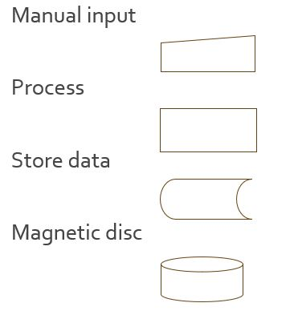

Flowchart sistem

Keunggulan utama penggunaan flowchart untuk mendeskripsikan sebuah sistem adalah kemampuannya memberikan gambaran yang intuitif dan menyeluruh tentang bagaimana seluruh komponen saling berinteraksi. Seorang analis sistem dapat melacak asal-usul data, melihat di mana data diproses, dan ke mana hasilnya disimpan atau dikirimkan, semua dalam satu diagram yang kohesif. Aliran yang digambarkan oleh anak panah membuatnya jelas untuk mengidentifikasi titik-titik keputusan, loop, dan potensi kemacetan dalam sistem. Dengan demikian, flowchart berfungsi sebagai blueprints yang sangat efektif untuk merancang, menganalisis, dan mendokumentasikan arsitektur dan proses suatu sistem komputer sebelum implementasi fisik atau pengembangan perangkat lunak dilakukan.

Berbeda dengan flowchart sistem yang berfokus pada interkoneksi perangkat keras, flowchart program berfokus pada alur logika dan proses data yang akan diimplementasikan ke dalam kode. Diagram ini menggunakan sekumpulan simbol standar yang masing-masing memiliki makna khusus: Terminal (oval) menandakan titik awal dan akhir algoritma, Preparation (segi enam) untuk inisialisasi variabel, Processing (persegi panjang) untuk operasi perhitungan atau penugasan nilai, Input/Output (jajaran genjang) untuk kegiatan membaca input atau menampilkan output, dan Decision (belah ketupat) untuk merepresentasikan percabangan logika seperti kondisi `IF`.

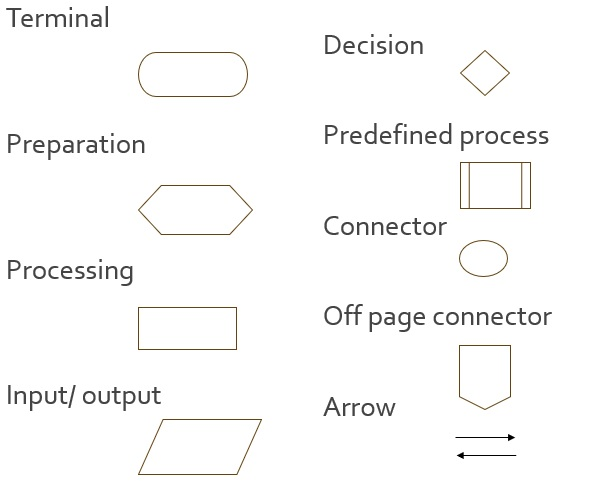

Flowchart program

Simbol-simbol lain melengkapi kompleksitas algoritma, di mana Predefined Process (persegi panjang dengan garis vertikal) digunakan untuk memanggil sub-prosedur atau fungsi yang telah didefinisikan terpisah, Connector (lingkaran kecil) sebagai penanda penghubung alur dalam halaman yang sama, dan Off-page Connector (segi lima) untuk menghubungkan alur yang terputus antar halaman berbeda. Semua simbol ini dihubungkan oleh Arrow (anak panah) yang menunjukkan arah dan urutan eksekusi dari satu langkah ke langkah berikutnya. Dengan memetakan setiap langkah ke dalam simbol-simbol intuitif ini, flowchart memberikan pemahaman yang cepat, jelas, dan bebas dari ambiguitas tentang struktur kontrol algoritma, sehingga menjadi alat yang sangat powerful dalam tahap perancangan, debugging, dan dokumentasi program.

Contoh flowchart program:

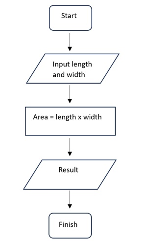

Flowchart progam menghitung luas persegi panjang